# File S2

Jullien Flynn

2017-08-08

This is the second part of analysis including for the paper “Rates and patterns of mutation in tandem repetitive DNA in six independent lineages of Chamydomonas reinhardtii”. This file goes through the analysis of mutation rates and patterns in genome-wide tandem repeats in 85 mutation accumulation lines from 6 ancestral strains of Chlamydomonas reinhardtii.

# Load in and process dataset

This dataset is the counts of all kmers found by k-Seek in the 85 MA lines analyzed. Before running k-Seek, the data have been trimmed using trimmomatic to remove low quality sequences. The kmer counts have been normalized by GC content and depth.

```r
data <- read.csv('/Users/jullienflynn/Documents/AndyLab/Chlamy/R_Analysis/data_in/Chlamy_trimmed_GCcorr.compiled')
file_names <- as.vector(data$X)
rownames(data) <- file_names
data[,1] <- NULL

# match the file names to the names of the lines
Chlamy_file_info <- read.delim("~/Documents/AndyLab/Chlamy/R_Analysis/info/Chlamy_file_info.txt", header=FALSE)
Chlamy_lines <- as.vector(Chlamy_file_info[,2])
Chlamy_files <- as.vector(Chlamy_file_info[,1])
names(Chlamy_lines) <- Chlamy_files
Chlamy_lines <- as.data.frame(Chlamy_lines)

data_withnames <- merge(data, Chlamy_lines, by=0)
lines <- data_withnames[,3314]
data_withnames <- data_withnames[,-c(1,3314)]
rownames(data_withnames) <- lines
data_withnames <- as.matrix(data_withnames)

# sort the columns (kmers) by their mean abundance
# here we want to remove the telomere repeat from mutation rate calculation
# remove the MA lines that do not have an accurate measure of generations
kmer_means <- colMeans(data_withnames)
data_sorted <- data_withnames[,order(kmer_means, decreasing=T)]
tel_column <- which (colnames(data_sorted) == "AAAACCCT")
data_sorted <- data_sorted[,-tel_column]
to_exclude <- c("CC-1373_MA15", "CC-2342_MA1", "CC-2342_MA2", "CC-2342_MA14")
ex <- which(rownames(data_sorted) %in% to_exclude)
data_sorted <- data_sorted[-ex,]
```

# Get the common kmers and make a matrix for each ancestor.

```r
# function that takes in a matrix of copy numbers and returns the indexes of kmers that have a mean copy number across all MA lines of at least 100
get_common_kmers <- function (kmer_matrix) {
  common.kmer.indexes <- c()
  for (i in 1:ncol(kmer_matrix)) {
    if (mean(kmer_matrix[,i])>=100) {
      common.kmer.indexes <- c(common.kmer.indexes, i)
    }
  }
  names(common.kmer.indexes) <- colnames(kmer_matrix)[common.kmer.indexes]
  return (common.kmer.indexes)
}

# make a new matrix for each ancestral group
data_1373 <- data_sorted[which (substr(rownames(data_sorted), start = 1, stop = 7) == "CC-1373"),  ]
data_1952 <- data_sorted[which (substr(rownames(data_sorted), start = 1, stop = 7) == "CC-1952"),  ]
data_2342 <- data_sorted[which (substr(rownames(data_sorted), start = 1, stop = 7) == "CC-2342"),  ]
data_2344 <- data_sorted[which (substr(rownames(data_sorted), start = 1, stop = 7) == "CC-2344"),  ]
data_2931 <- data_sorted[which (substr(rownames(data_sorted), start = 1, stop = 7) == "CC-2931"),  ]
data_2937 <- data_sorted[which (substr(rownames(data_sorted), start = 1, stop = 7) == "CC-2937"),  ]

# get the common kmer indexes for each ancestral group, and how many each has
common.kmer.indexes_1373 <- get_common_kmers(data_1373)
common.kmer.indexes_1952 <- get_common_kmers(data_1952)
common.kmer.indexes_2342 <- get_common_kmers(data_2342)
common.kmer.indexes_2344 <- get_common_kmers(data_2344)
common.kmer.indexes_2931 <- get_common_kmers(data_2931)
common.kmer.indexes_2937 <- get_common_kmers(data_2937)

# get the common kmer union
common.kmer.union <- Reduce(union, list
       (names(common.kmer.indexes_1373), names(common.kmer.indexes_1952),
       names(common.kmer.indexes_2342), names(common.kmer.indexes_2344),
       names(common.kmer.indexes_2931), names(common.kmer.indexes_2937)
       ))
# get the indexes of the common kmer union
common.kmer.union.indexes <- Reduce(union, list
       (common.kmer.indexes_1373, common.kmer.indexes_1952,
       common.kmer.indexes_2342, common.kmer.indexes_2344,
       common.kmer.indexes_2931, common.kmer.indexes_2937
       ))
```

# Calculate mutation rates

```r
# import the generation data
chlamy_generations <- read.csv("~/Documents/AndyLab/Chlamy/R_Analysis/info/chlamy_generations.csv")
generation_names <- as.vector(chlamy_generations[,1])
chlamy_generations <- as.vector(chlamy_generations[,2])
names(chlamy_generations) <- generation_names

# function that makes a deviation matrix from an input kmer copy number matrix and the indexes to be included
get_deviation <- function (kmer_matrix, kmer.indexes) {
  kmer.deviation.matrix <- matrix(nrow=nrow(kmer_matrix), ncol=max(kmer.indexes))
  for (i in 1:max(kmer.indexes)) {
    for (j in 1:nrow(kmer_matrix)){
      kmer.deviation.matrix[j,i] <- kmer_matrix[j,i] - mean(kmer_matrix[,i])
    }
  }
  # only include the intended columns
  result <- kmer.deviation.matrix[,kmer.indexes]
  rownames(result) <- rownames(kmer_matrix)
  colnames(result) <- names(kmer.indexes)
  return (result)
}


# calculate mutation rates for all ancestors: assign generations, make deviation matrix, calculate mutation rates and the absolute value of mutation rates (absolute value of + and - changes)

# CC-1373
generations_1373 <- chlamy_generations[grepl("CC-1373", names(chlamy_generations), fixed=FALSE)]
generations_1373 <- generations_1373[-13]
kmer_deviation_1373 <- get_deviation(data_1373, common.kmer.indexes_1373)
mu_1373 <- kmer_deviation_1373/generations_1373
mu_abs_1373 <- (abs(kmer_deviation_1373))/generations_1373


# CC-1952
generations_1952 <- chlamy_generations[grepl("CC-1952", names(chlamy_generations), fixed=FALSE)]
kmer_deviation_1952 <- get_deviation(data_1952, common.kmer.indexes_1952)
mu_1952 <- kmer_deviation_1952/generations_1952
mu_abs_1952 <- (abs(kmer_deviation_1952))/generations_1952

# CC-2342
generations_2342 <- chlamy_generations[grepl("CC-2342", names(chlamy_generations), fixed=FALSE)]
generations_2342 <- generations_2342[-c(1,2,13)]
kmer_deviation_2342 <- get_deviation(data_2342, common.kmer.indexes_2342)
mu_2342 <- kmer_deviation_2342/generations_2342
mu_abs_2342 <- (abs(kmer_deviation_2342))/generations_2342

# CC-2344
generations_2344 <- chlamy_generations[grepl("CC-2344", names(chlamy_generations), fixed=FALSE)]
kmer_deviation_2344 <- get_deviation(data_2344, common.kmer.indexes_2344)
mu_2344 <- kmer_deviation_2344/generations_2344
mu_abs_2344 <- (abs(kmer_deviation_2344))/generations_2344

# CC-2931
generations_2931 <- chlamy_generations[grepl("CC-2931", names(chlamy_generations), fixed=FALSE)]
kmer_deviation_2931 <- get_deviation(data_2931, common.kmer.indexes_2931)
mu_2931 <- kmer_deviation_2931/generations_2931
mu_abs_2931 <- (abs(kmer_deviation_2931))/generations_2931

# CC-2937
generations_2937 <- chlamy_generations[grepl("CC-2937", names(chlamy_generations), fixed=FALSE)]
kmer_deviation_2937 <- get_deviation(data_2937, common.kmer.indexes_2937)
mu_2937 <- kmer_deviation_2937/generations_2937
mu_abs_2937 <- (abs(kmer_deviation_2937))/generations_2937
```

# Linear relationship between kmer copy number and mutation rate

```r
# CC-1373
mu_abs_1373_perkmer <-  colMeans(mu_abs_1373)
abundance_avg_1373 <- colMeans(data_1373[,common.kmer.indexes_1373])
names(mu_abs_1373_perkmer) == names(abundance_avg_1373)
```

```
##  [1] TRUE TRUE TRUE TRUE TRUE TRUE TRUE TRUE TRUE TRUE TRUE TRUE TRUE TRUE
## [15] TRUE TRUE TRUE TRUE TRUE TRUE TRUE TRUE TRUE TRUE TRUE TRUE TRUE
```

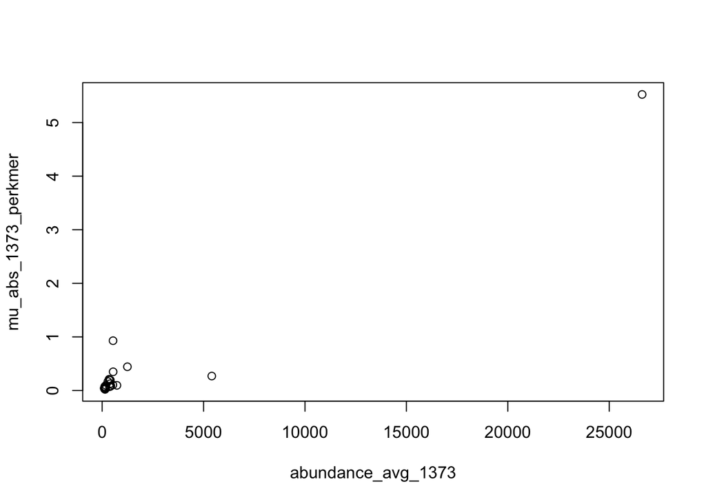

```r
plot(x = abundance_avg_1373, y = mu_abs_1373_perkmer)
```

```r
summary(lm(formula = mu_abs_1373_perkmer ~ abundance_avg_1373))
```

```
##
## Call:
## lm(formula = mu_abs_1373_perkmer ~ abundance_avg_1373)
##
## Residuals:
##      Min       1Q   Median       3Q      Max
## -0.86131 -0.04901 -0.03229  0.06203  0.77180
##
## Coefficients:
##                     Estimate Std. Error t value Pr(>|t|)
## (Intercept)        5.040e-02  4.877e-02   1.033    0.311
## abundance_avg_1373 1.999e-04  9.301e-06  21.488   <2e-16 ***
## ---
## Signif. codes:  0 '***' 0.001 '**' 0.01 '*' 0.05 '.' 0.1 ' ' 1
##
## Residual standard error: 0.243 on 25 degrees of freedom
## Multiple R-squared:  0.9486, Adjusted R-squared:  0.9466
## F-statistic: 461.7 on 1 and 25 DF,  p-value: < 2.2e-16
```

```r
# CC-1952
mu_abs_1952_perkmer <-  colMeans(mu_abs_1952)
abundance_avg_1952 <- colMeans(data_1952[,common.kmer.indexes_1952])
names(mu_abs_1952_perkmer) == names(abundance_avg_1952)
```

```
##  [1] TRUE TRUE TRUE TRUE TRUE TRUE TRUE TRUE TRUE TRUE TRUE TRUE TRUE TRUE
## [15] TRUE TRUE TRUE TRUE TRUE TRUE TRUE TRUE TRUE TRUE TRUE TRUE TRUE TRUE
## [29] TRUE TRUE
```

```r
summary(lm(formula = mu_abs_1952_perkmer ~ abundance_avg_1952))
```

```
##
## Call:
## lm(formula = mu_abs_1952_perkmer ~ abundance_avg_1952)
##
## Residuals:
##      Min       1Q   Median       3Q      Max
## -1.09181 -0.06261 -0.04712 -0.01452  1.14393
##
## Coefficients:
##                     Estimate Std. Error t value Pr(>|t|)
## (Intercept)        6.380e-02  5.996e-02   1.064    0.296
## abundance_avg_1952 1.874e-04  1.126e-05  16.641 4.74e-16 ***
## ---
## Signif. codes:  0 '***' 0.001 '**' 0.01 '*' 0.05 '.' 0.1 ' ' 1
##
## Residual standard error: 0.315 on 28 degrees of freedom
## Multiple R-squared:  0.9082, Adjusted R-squared:  0.9049
## F-statistic: 276.9 on 1 and 28 DF,  p-value: 4.735e-16
```

```r
# CC-2342
mu_abs_2342_perkmer <-  colMeans(mu_abs_2342)
abundance_avg_2342 <- colMeans(data_2342[,common.kmer.indexes_2342])
names(mu_abs_2342_perkmer) == names(abundance_avg_2342)
```

```
##  [1] TRUE TRUE TRUE TRUE TRUE TRUE TRUE TRUE TRUE TRUE TRUE TRUE TRUE TRUE
## [15] TRUE TRUE TRUE TRUE TRUE TRUE TRUE TRUE TRUE TRUE TRUE TRUE TRUE TRUE
## [29] TRUE
```

```r
summary(lm(formula = mu_abs_2342_perkmer ~ abundance_avg_2342))
```

```
##
## Call:
## lm(formula = mu_abs_2342_perkmer ~ abundance_avg_2342)
##
## Residuals:
##      Min       1Q   Median       3Q      Max
## -1.21168 -0.11194 -0.08465  0.03645  1.58679
##
## Coefficients:
##                     Estimate Std. Error t value Pr(>|t|)
## (Intercept)        1.278e-01  8.345e-02   1.531    0.137
## abundance_avg_2342 2.172e-04  1.307e-05  16.621 1.05e-15 ***
## ---
## Signif. codes:  0 '***' 0.001 '**' 0.01 '*' 0.05 '.' 0.1 ' ' 1
##
## Residual standard error: 0.4306 on 27 degrees of freedom
## Multiple R-squared:  0.911,  Adjusted R-squared:  0.9077
## F-statistic: 276.3 on 1 and 27 DF,  p-value: 1.047e-15
```

```r
# CC-2344
mu_abs_2344_perkmer <-  colMeans(mu_abs_2344)
abundance_avg_2344 <- colMeans(data_2344[,common.kmer.indexes_2344])
names(mu_abs_2344_perkmer) == names(abundance_avg_2344)
```

```
##  [1] TRUE TRUE TRUE TRUE TRUE TRUE TRUE TRUE TRUE TRUE TRUE TRUE TRUE TRUE
## [15] TRUE TRUE TRUE TRUE TRUE TRUE TRUE TRUE TRUE TRUE TRUE
```

```r
summary(lm(formula = mu_abs_2344_perkmer ~ abundance_avg_2344))
```

```
##
## Call:
## lm(formula = mu_abs_2344_perkmer ~ abundance_avg_2344)
##
## Residuals:
##      Min       1Q   Median       3Q      Max
## -0.90624 -0.05962 -0.04859 -0.01332  0.83553
##
## Coefficients:
##                     Estimate Std. Error t value Pr(>|t|)
## (Intercept)        5.483e-02  5.838e-02   0.939    0.357
## abundance_avg_2344 1.602e-04  8.123e-06  19.720 6.58e-16 ***
## ---
## Signif. codes:  0 '***' 0.001 '**' 0.01 '*' 0.05 '.' 0.1 ' ' 1
##
## Residual standard error: 0.2802 on 23 degrees of freedom
## Multiple R-squared:  0.9442, Adjusted R-squared:  0.9417
## F-statistic: 388.9 on 1 and 23 DF,  p-value: 6.576e-16
```

```r
# CC-2931
mu_abs_2931_perkmer <-  colMeans(mu_abs_2931)
abundance_avg_2931 <- colMeans(data_2931[,common.kmer.indexes_2931])
names(mu_abs_2931_perkmer) == names(abundance_avg_2931)
```

```
##  [1] TRUE TRUE TRUE TRUE TRUE TRUE TRUE TRUE TRUE TRUE TRUE TRUE TRUE TRUE
## [15] TRUE TRUE TRUE TRUE TRUE TRUE TRUE TRUE TRUE TRUE TRUE TRUE TRUE TRUE
```

```r
summary(lm(formula = mu_abs_2931_perkmer ~ abundance_avg_2931))
```

```
##
## Call:
## lm(formula = mu_abs_2931_perkmer ~ abundance_avg_2931)
##
## Residuals:
##      Min       1Q   Median       3Q      Max
## -1.27095 -0.04690 -0.02244 -0.00108  0.55807
##
## Coefficients:
##                     Estimate Std. Error t value Pr(>|t|)
## (Intercept)        1.732e-02  6.166e-02   0.281    0.781
## abundance_avg_2931 2.348e-04  1.006e-05  23.337   <2e-16 ***
## ---
## Signif. codes:  0 '***' 0.001 '**' 0.01 '*' 0.05 '.' 0.1 ' ' 1
##
## Residual standard error: 0.312 on 26 degrees of freedom
## Multiple R-squared:  0.9544, Adjusted R-squared:  0.9527
## F-statistic: 544.6 on 1 and 26 DF,  p-value: < 2.2e-16
```

```r
# CC-2937
mu_abs_2937_perkmer <-  colMeans(mu_abs_2937)
abundance_avg_2937 <- colMeans(data_2937[,common.kmer.indexes_2937])
names(mu_abs_2937_perkmer) == names(abundance_avg_2937)
```

```
##  [1] TRUE TRUE TRUE TRUE TRUE TRUE TRUE TRUE TRUE TRUE TRUE TRUE TRUE TRUE
## [15] TRUE TRUE TRUE TRUE TRUE TRUE TRUE TRUE TRUE TRUE TRUE TRUE TRUE TRUE
```

```r
summary(lm(formula = mu_abs_2937_perkmer ~ abundance_avg_2937))
```

```
##
## Call:
## lm(formula = mu_abs_2937_perkmer ~ abundance_avg_2937)
##
## Residuals:
##      Min       1Q   Median       3Q      Max
## -1.17356 -0.05162 -0.03422  0.01292  0.91247
##
## Coefficients:
##                     Estimate Std. Error t value Pr(>|t|)
## (Intercept)        4.905e-02  6.213e-02    0.79    0.437
## abundance_avg_2937 2.234e-04  1.179e-05   18.95   <2e-16 ***
## ---
## Signif. codes:  0 '***' 0.001 '**' 0.01 '*' 0.05 '.' 0.1 ' ' 1
##
## Residual standard error: 0.3136 on 26 degrees of freedom
## Multiple R-squared:  0.9325, Adjusted R-squared:  0.9299
## F-statistic: 359.1 on 1 and 26 DF,  p-value: < 2.2e-16
```

## Get the absolute mutation rate range

```r
range(mu_abs_1373_perkmer)
```

```
## [1] 0.02063904 5.52423316
```

```r
range(mu_abs_1952_perkmer)
```

```
## [1] 0.01561974 5.56103158
```

```r
range(mu_abs_2342_perkmer)
```

```
## [1] 0.02787081 7.47900960
```

```r
range(mu_abs_2344_perkmer)
```

```
## [1] 0.01645503 5.84297042
```

```r
range(mu_abs_2931_perkmer)
```

```
## [1] 0.02044595 7.63168077
```

```r
range(mu_abs_2937_perkmer)
```

```
## [1] 0.02057838 6.30187559
```

# Normalize mutation rates for each ancestor

```r
# make matrices of mutation rates normalized by the initial abundance of the kmer

# first get the abundance averages of all kmers
abundance_avg_1373 <- colMeans(data_1373[,common.kmer.indexes_1373])
abundance_avg_1952 <- colMeans(data_1952[,common.kmer.indexes_1952])
abundance_avg_2342 <- colMeans(data_2342[,common.kmer.indexes_2342])
abundance_avg_2344 <- colMeans(data_2344[,common.kmer.indexes_2344])
abundance_avg_2931 <- colMeans(data_2931[,common.kmer.indexes_2931])
abundance_avg_2937 <- colMeans(data_2937[,common.kmer.indexes_2937])

colnames(data_1373[,common.kmer.indexes_1373])
```

```
##  [1] "AC"                  "AGC"                 "C"
##  [4] "AGGCGG"              "AAT"                 "AGGC"
##  [7] "ACGC"                "AAC"                 "ACACGC"
## [10] "AAATACCTTACGGGAATAT" "AGGCGC"              "ACCGGC"
## [13] "CCG"                 "ACC"                 "AGGGC"
## [16] "ACCCGC"              "AAATAACAAT"          "AGCGGC"
## [19] "AAAGT"               "AGG"                 "ACAGGG"
## [22] "ATC"                 "ACGCCC"              "AAATACTTACGGGAATAT"
## [25] "AGCGCC"              "AGCGGG"              "ACCCGG"
```

```r
names(abundance_avg_1373) # these are in the same order
```

```
##  [1] "AC"                  "AGC"                 "C"
##  [4] "AGGCGG"              "AAT"                 "AGGC"
##  [7] "ACGC"                "AAC"                 "ACACGC"
## [10] "AAATACCTTACGGGAATAT" "AGGCGC"              "ACCGGC"
## [13] "CCG"                 "ACC"                 "AGGGC"
## [16] "ACCCGC"              "AAATAACAAT"          "AGCGGC"
## [19] "AAAGT"               "AGG"                 "ACAGGG"
## [22] "ATC"                 "ACGCCC"              "AAATACTTACGGGAATAT"
## [25] "AGCGCC"              "AGCGGG"              "ACCCGG"
```

```r
# now make the matrices
mu_absnorm_1373 <- t (t(mu_abs_1373)/abundance_avg_1373)
mu_absnorm_1952 <- t (t(mu_abs_1952)/abundance_avg_1952)
mu_absnorm_2342 <- t (t(mu_abs_2342)/abundance_avg_2342)
mu_absnorm_2344 <- t (t(mu_abs_2344)/abundance_avg_2344)
mu_absnorm_2931 <- t (t(mu_abs_2931)/abundance_avg_2931)
mu_absnorm_2937 <- t (t(mu_abs_2937)/abundance_avg_2937)

# directional normalized

munorm_1373 <- t (t(mu_1373)/abundance_avg_1373)
munorm_1952 <- t (t(mu_1952)/abundance_avg_1952)
munorm_2342 <- t (t(mu_2342)/abundance_avg_2342)
munorm_2344 <- t (t(mu_2344)/abundance_avg_2344)
munorm_2931 <- t (t(mu_2931)/abundance_avg_2931)
munorm_2937 <- t (t(mu_2937)/abundance_avg_2937)

abundance_avg_2931
```

```
##                   AC                  AGC                    C
##           31574.7143            6663.2857            1494.0714
##               AGGCGG                  AAT                 AGGC
##            1044.7143            1043.4286             704.3571
##       AAATAGCAGTATAT                 ACGC                  AAC
##            1896.2857             616.2857             231.1429
##               ACACGC               AGGCGC               ACCGGC
##             571.0714             368.6429             301.7143
##         AAAATAAAGTGT                  CCG                  ACC
##             646.2857             129.7143             197.5000
##                AGGGC               ACCCGC               ACAGGC
##             234.5000             234.4286             379.0000
##               AGCGGC                AAAGT                  AGG
##             165.2143             155.5714             130.4286
##               ACCAGC               ACAGGG                  ATC
##             202.7143             192.5000             323.7857
##               ACGCCC AAAAAGGTAAATGTATTTAT                ACGCC
##             180.2143             317.7857             110.0714
##              ACTGGGC
##             121.1429
```

```r
names(abundance_avg_2931) == colnames(mu_absnorm_2931)
```

```
##  [1] TRUE TRUE TRUE TRUE TRUE TRUE TRUE TRUE TRUE TRUE TRUE TRUE TRUE TRUE
## [15] TRUE TRUE TRUE TRUE TRUE TRUE TRUE TRUE TRUE TRUE TRUE TRUE TRUE TRUE
```

```r
names(abundance_avg_1373) == colnames(mu_absnorm_1373)
```

```
##  [1] TRUE TRUE TRUE TRUE TRUE TRUE TRUE TRUE TRUE TRUE TRUE TRUE TRUE TRUE
## [15] TRUE TRUE TRUE TRUE TRUE TRUE TRUE TRUE TRUE TRUE TRUE TRUE TRUE
```

# Import in the strings of the 18 shared kmers

```r
# import in the shared common kmers
shared.common.kmers <- read.csv("~/Documents/AndyLab/Chlamy/R_Analysis/data_in/chlamy_shared.common.kmers.txt", sep="", header=F)
shared.common.kmers <- as.vector(shared.common.kmers[,1])
shared.common.kmers
```

```
##  [1] "AC"       "AGC"      "AAAACCCT" "C"        "AGGCGG"   "AAT"
##  [7] "AGGC"     "ACGC"     "AAC"      "ACACGC"   "AGGCGC"   "ACCGGC"
## [13] "CCG"      "ACC"      "AGGGC"    "ACCCGC"   "AGCGGC"   "AGG"
```

# De novo gain/loss of kmers within the MA experiments

## New kmers from each ancestor

1. For each ancestor, make a matrix with all the kmers that are present in them.

```r
# make matrix of all kmers to consider for each ancestor
# consider all kmers that have at least one MA line with at least 2 copies

# function that generates a matrix containing al kmers that have at least 1 sample with 2 copies
get_allkmers <- function (kmer_mx, indexes) {
  all_mx <- as.matrix(kmer_mx[,indexes]) # start with small matrix then add to it
  for (i in (max(indexes)+1):ncol(kmer_mx)){ ## go through all columns in data
    counter <- 0
    for (j in 1:nrow(kmer_mx)) {
      if (kmer_mx[j,i] > 2 ) {
        counter <- counter + 1
      }
    }
    if (counter > 0) { ## if there is at least one sample with 2 copies of this kmer, add it to the new matrix
    all_mx <- cbind(all_mx[, , drop=FALSE], kmer_mx[,i, drop=FALSE])
  }
  }
  return (all_mx)
}

kmers.all_1373 <- get_allkmers(data_1373, common.kmer.indexes_1373)
kmers.all_1952 <- get_allkmers(data_1952, common.kmer.indexes_1952)
kmers.all_2342 <- get_allkmers(data_2342, common.kmer.indexes_2342)
kmers.all_2344 <- get_allkmers(data_2344, common.kmer.indexes_2344)
kmers.all_2931 <- get_allkmers(data_2931, common.kmer.indexes_2931)
kmers.all_2937 <- get_allkmers(data_2937, common.kmer.indexes_2937)
```

2. Function that gets new kmers unique to 1 MA line (will just use n=1). Note: repeat for each ancestor.

```r
get_new_kmers <- function (all_kmer_mx, nlines) {
  kmers.new <- matrix(nrow=nrow(all_kmer_mx)) # make new empty matrix
  for (i in 1:ncol(all_kmer_mx)) { ## go through each column of the data
    uniq <- all_kmer_mx[,i] > 0 # uniq will be true and false
    if (sum(uniq)==nlines) { # if only there are nlines true elements, add to matrix
      kmers.new <- cbind(kmers.new[, , drop=FALSE], all_kmer_mx[,i, drop=FALSE])
    }
  }
  kmers.new <- kmers.new[,2:ncol(kmers.new)] # remove first column, which is all NA
  return(kmers.new)
}

unique.kmers_1373  <- get_new_kmers(kmers.all_1373, 1)
unique.kmers_1373
```

```
##              ACCCCG AGCGGGAGGGGC ACG ACCCGCGCCGCT AGATCGGGAGCGCCC
## CC-1373_MA1       0            0   0            0               0
## CC-1373_MA2       0            0   0            0               0
## CC-1373_MA3       0            0   0            0               0
## CC-1373_MA4       0            0   5            0               0
## CC-1373_MA5       0            0   0            0               0
## CC-1373_MA6       0            0   0            0               0
## CC-1373_MA7       0            0   0            0               0
## CC-1373_MA8       0            0   0            0               0
## CC-1373_MA10      0            3   0            3               0
## CC-1373_MA11      0            0   0            0               4
## CC-1373_MA13      0            0   0            0               0
## CC-1373_MA14      3            0   0            0               0
##              ACCCTGGGCCTG ACGCCCGC
## CC-1373_MA1             0        0
## CC-1373_MA2             0        3
## CC-1373_MA3             0        0
## CC-1373_MA4             3        0
## CC-1373_MA5             0        0
## CC-1373_MA6             0        0
## CC-1373_MA7             0        0
## CC-1373_MA8             0        0
## CC-1373_MA10            0        0
## CC-1373_MA11            0        0
## CC-1373_MA13            0        0
## CC-1373_MA14            0        0
```

```r
colnames(unique.kmers_1373)
```

```
## [1] "ACCCCG"          "AGCGGGAGGGGC"    "ACG"             "ACCCGCGCCGCT"
## [5] "AGATCGGGAGCGCCC" "ACCCTGGGCCTG"    "ACGCCCGC"
```

```r
unique.kmers_1952  <- get_new_kmers(kmers.all_1952, 1)
unique.kmers_1952
```

```
##              ACATGC ACGGG AGAGCC AGCCTC CCCCG AGGCGGG ACCTCCCC ACCCTCC
## CC-1952_MA1       0     0      0      0     0       0        0       0
## CC-1952_MA2       0     3      0      0     0       0        0       0
## CC-1952_MA3       0     0      0      0     0       0        0       0
## CC-1952_MA4       0     0      0      0     0       0        0       0
## CC-1952_MA5       0     0      3     10     0       0        0       0
## CC-1952_MA6       0     0      0      0     0       0        0       0
## CC-1952_MA7       0     0      0      0     0       0        0       0
## CC-1952_MA8       0     0      0      0     0       0        0       0
## CC-1952_MA10      0     0      0      0     0       0        0       0
## CC-1952_MA11      3     0      0      0     0       0        0       0
## CC-1952_MA12      0     0      0      0     0       0        0       0
## CC-1952_MA13      0     0      0      0     3      15        3       3
## CC-1952_MA14      0     0      0      0     0       0        0       0
## CC-1952_MA15      0     0      0      0     0       0        0       0
##              ACACCCTCCCCGGCCCCG AGGAGGGGGGC AGGCAGGGGCC ACCCCAG
## CC-1952_MA1                   0           0           0       0
## CC-1952_MA2                   0           0           0       0
## CC-1952_MA3                   0           0           0       0
## CC-1952_MA4                   0           0           0       0
## CC-1952_MA5                   0           0           0       0
## CC-1952_MA6                   0           0           0       0
## CC-1952_MA7                   0           0           0       0
## CC-1952_MA8                  10           8           7       4
## CC-1952_MA10                  0           0           0       0
## CC-1952_MA11                  0           0           0       0
## CC-1952_MA12                  0           0           0       0
## CC-1952_MA13                  0           0           0       0
## CC-1952_MA14                  0           0           0       0
## CC-1952_MA15                  0           0           0       0
##              AGAGGCGGGCAGGCGGG CCCCCGG ACCCCCTCCCCTCCCTG AGCGG
## CC-1952_MA1                  0       0                 0     0
## CC-1952_MA2                  0       0                 0     0
## CC-1952_MA3                  0       0                 0     0
## CC-1952_MA4                  0       0                 0     0
## CC-1952_MA5                  0       0                 0     0
## CC-1952_MA6                  0       0                 0     0
## CC-1952_MA7                  0       0                 0     0
## CC-1952_MA8                  0       0                 0     0
## CC-1952_MA10                 0       0                 0     0
## CC-1952_MA11                 0       0                 0     0
## CC-1952_MA12                 0       0                 0     0
## CC-1952_MA13                 4       4                 3     0
## CC-1952_MA14                 0       0                 0     0
## CC-1952_MA15                 0       0                 0     3
##              ACGGAGCGGCGGCTCGGG
## CC-1952_MA1                   0
## CC-1952_MA2                   0
## CC-1952_MA3                   0
## CC-1952_MA4                   0
## CC-1952_MA5                   0
## CC-1952_MA6                   0
## CC-1952_MA7                   0
## CC-1952_MA8                   0
## CC-1952_MA10                  0
## CC-1952_MA11                  0
## CC-1952_MA12                  0
## CC-1952_MA13                  3
## CC-1952_MA14                  0
## CC-1952_MA15                  0
```

```r
colnames(unique.kmers_1952)
```

```
##  [1] "ACATGC"             "ACGGG"              "AGAGCC"
##  [4] "AGCCTC"             "CCCCG"              "AGGCGGG"
##  [7] "ACCTCCCC"           "ACCCTCC"            "ACACCCTCCCCGGCCCCG"
## [10] "AGGAGGGGGGC"        "AGGCAGGGGCC"        "ACCCCAG"
## [13] "AGAGGCGGGCAGGCGGG"  "CCCCCGG"            "ACCCCCTCCCCTCCCTG"
## [16] "AGCGG"              "ACGGAGCGGCGGCTCGGG"
```

```r
# 8/17 new kmers are in MA 13

intersect(colnames(unique.kmers_1373), colnames(unique.kmers_1952))
```

```
## character(0)
```

```r
unique.kmers_2342  <- get_new_kmers(kmers.all_2342, 1)
unique.kmers_2342
```

```
##              AGGGCCGGGGCC AACCACGCAACCGCGC AACCGCGC AAGCGGGCAAGGCGTG ACCCC
## CC-2342_MA3             0                0        0                0     0
## CC-2342_MA4             0                0        0                0     0
## CC-2342_MA5             0                0        0                0    30
## CC-2342_MA7             0                0        0                0     0
## CC-2342_MA8             0                0        0                0     0
## CC-2342_MA9             0                0        0                0     0
## CC-2342_MA10            0                0        0                0     0
## CC-2342_MA11            0                0        0                0     0
## CC-2342_MA12            7               31       19               21     0
## CC-2342_MA13            0                0        0                0     0
## CC-2342_MA15            0                0        0                0     0
##              AAGCCGTGGCAGGTGTGG AACCT AAG ACCGCCGCCCCCTCCTC ACCCCC
## CC-2342_MA3                   0     0   0                 0      0
## CC-2342_MA4                   0     0   0                 0      0
## CC-2342_MA5                   0     0   5                21     24
## CC-2342_MA7                   0     0   0                 0      0
## CC-2342_MA8                   0     0   0                 0      0
## CC-2342_MA9                   0     0   0                 0      0
## CC-2342_MA10                  0     0   0                 0      0
## CC-2342_MA11                  0     0   0                 0      0
## CC-2342_MA12                 11     0   0                 0      0
## CC-2342_MA13                  0     4   0                 0      0
## CC-2342_MA15                  0     0   0                 0      0
##              AGGGCGGCG ACCC CCCGCG AGGGGCCGGG ACCTCGGCCCTGCCCC
## CC-2342_MA3          0    0      0          0                0
## CC-2342_MA4          0    0      0          0                0
## CC-2342_MA5          0    9      0         12                5
## CC-2342_MA7          0    0      0          0                0
## CC-2342_MA8          0    0      0          0                0
## CC-2342_MA9          0    0      0          0                0
## CC-2342_MA10         0    0      0          0                0
## CC-2342_MA11         0    0      0          0                0
## CC-2342_MA12         0    0      0          0                0
## CC-2342_MA13         4    0      8          0                0
## CC-2342_MA15         0    0      0          0                0
##              AGCCCCCGCCTCCCCCTCC ACTCCCCGCCTCTCCCCC ACCTCCCC
## CC-2342_MA3                    0                  0        0
## CC-2342_MA4                    0                  0        0
## CC-2342_MA5                    8                  9        4
```

[output cut: 65 more lines]

```
## CC-2342_MA12                 0    3          0             0
## CC-2342_MA13                 0    0          0             0
## CC-2342_MA15                 0    0          0             0
##              ACCGCCGCCCCCCCCTC
## CC-2342_MA3                  0
## CC-2342_MA4                  0
## CC-2342_MA5                  3
## CC-2342_MA7                  0
## CC-2342_MA8                  0
## CC-2342_MA9                  0
## CC-2342_MA10                 0
## CC-2342_MA11                 0
## CC-2342_MA12                 0
## CC-2342_MA13                 0
## CC-2342_MA15                 0
```